# Capstone Milestone

leosum

November 27, 2016

## Introduction

The goal of this report is to display that I’ve gotten used to working with the data and that I am on track to create my prediction algorithm for the Coursera Data Science John Hopkins University Capstone.

The report explains my exploratory analysis, the major features of the data I have identified and briefly summarize my plans for creating the prediction algorithm and Shiny app.

## Get and Load data

Load useful packages:

```r
library("tm")
library("data.table")
library("RCurl")
library("SnowballC")
library("stringi")
library("wordcloud")
library("ggplot2")
library("RWeka")
library("RColorBrewer")
library("Matrix")
```

Get the data and a bad word list:

```r
if (!file.exists(unzipped_blogs_file) |
    !file.exists(unzipped_twitter_file) |
    !file.exists(unzipped_news_file))
  {
   zipfile <- "../Coursera-SwiftKey.zip"
   if (!file.exists(zipfile)) {
      url <- download.file("http://d396qusza40orc.cloudfront.net/dsscapstone/dataset/Coursera-SwiftKey.zip",
             destfile = zipfile, mode = "wb")
    }
   unzip(zipfile, exdir = "../Coursera-SwiftKey")
  }
```

```r
if (!file.exists(badwords)) {
  url <- "https://raw.githubusercontent.com/LDNOOBW/List-of-Dirty-Naughty-Obscene-and-Otherwise-Bad-Words/master/en"
  bad_word <- getURL(url)
  bad_word <- readLines(textConnection(bad_word))
  writeLines(bad_word, "data/badwords.txt")
}
```

## Basic report of summary statistics about the data sets

The twitter file is 159.364069 MB

The news file is 196.2775126 MB

We create and inspect our Corpus and notice as expected our 3 documents. For each document we can see the number of characters it contains:

```r
twitter <- readLines(con_twitter, warn = F)
news <- readLines(con_news,encoding= "UTF-8", warn = F)
blogs <- readLines(con_blogs,encoding= "UTF-8", warn = F)
documents <- Corpus(DirSource(p_dir))
inspect(documents)
```

```
## <<VCorpus>>
## Metadata:  corpus specific: 0, document level (indexed): 0
## Content:  documents: 3
##
## [[1]]
## <<PlainTextDocument>>
## Metadata:  7
## Content:  chars: 208361438
##
## [[2]]
## <<PlainTextDocument>>
## Metadata:  7
## Content:  chars: 15683765
##
## [[3]]
## <<PlainTextDocument>>
## Metadata:  7
## Content:  chars: 162384825
```

The details into a table:

```r
print(documentSummary(documents))
```

```
##                     Lines    Words     Chars
## en_US.blogs.txt    899288 37334441 208361438
## en_US.news.txt      77259  2643972  15683765
## en_US.twitter.txt 2360148 30373792 162384825
```

## Sampling data

Sampling the Corpus:

```r
sampleRatio <- 0.1
r_all <- documents
for(i in seq(r_all)) {
  r_all[[i]]$content <- sample(r_all[[i]]$content, length(r_all[[i]]$content) * sampleRatio )
}
inspect(r_all)
```

```
## <<VCorpus>>
## Metadata:  corpus specific: 0, document level (indexed): 0
## Content:  documents: 3
##
## [[1]]
## <<PlainTextDocument>>
## Metadata:  7
## Content:  chars: 20918681
##
## [[2]]
## <<PlainTextDocument>>
## Metadata:  7
## Content:  chars: 1572871
##
## [[3]]
## <<PlainTextDocument>>
## Metadata:  7
## Content:  chars: 16216697
```

Now again with the inspection of the Corpus we can see we do get 10% of the characteres for each files. We will work from now on exclusively with this sample Corpus, a corpora grouping a sample of the three files.

## Clean the corpus

We proceed with cleaning the corpora from spurious characteres and words as follow:

```r
basecleanCorpus <- function(corpus){
  corpus <- tm_map(corpus, removePunctuation)                # Remove punctuation
  corpus <- tm_map(corpus, removeNumbers)                    # Removing numbers
  corpus <- tm_map(corpus, tolower)                          # Convert to Lower Case
  corpus <- tm_map(corpus, removeWords, my_stop_words_text)  # Remove bad word
  corpus <- tm_map(corpus, stripWhitespace)                  # Eliminating Extra Whitespace
  corpus <- tm_map(corpus, PlainTextDocument)
  corpus
}
cleanCorpus <- function(corpus){
  corpus <- tm_map(corpus, removePunctuation)
  corpus <- tm_map(corpus, removeNumbers)
  corpus <- tm_map(corpus, tolower)
  corpus <- tm_map(corpus, removeWords, my_stop_words_text)
  corpus <- tm_map(corpus, removeWords, stopwords("english")) # Remove English stopwords
  corpus <- tm_map(corpus, stemDocument)                      # Stemming
  corpus <- tm_map(corpus, stripWhitespace)
  corpus <- tm_map(corpus, PlainTextDocument)
  corpus
}
corpusAllClean <- cleanCorpus(r_all)
```

[output not shown]

## Exploratory

We create a document term matrix and get a glance of the most frequent words in the corpora via a cloud image:

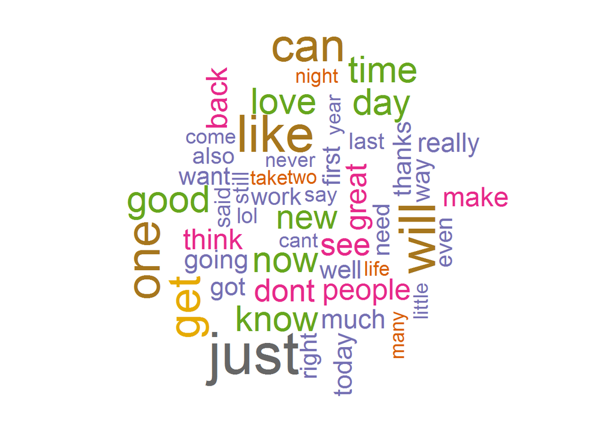

```r
dtm_all <- DocumentTermMatrix(corpusAllClean)
#dtm_all_base <- DocumentTermMatrix(basecorpusAllClean)
frequencyWords <- sort(colSums(as.matrix(dtm_all)), decreasing=TRUE)
set.seed(100)
wordcloud(names(frequencyWords), frequencyWords, max.words=50, rot.per=0.2, colors=brewer.pal(8, "Dark2"))
```

Let’s plot the 10 most frequent words in the corpora:

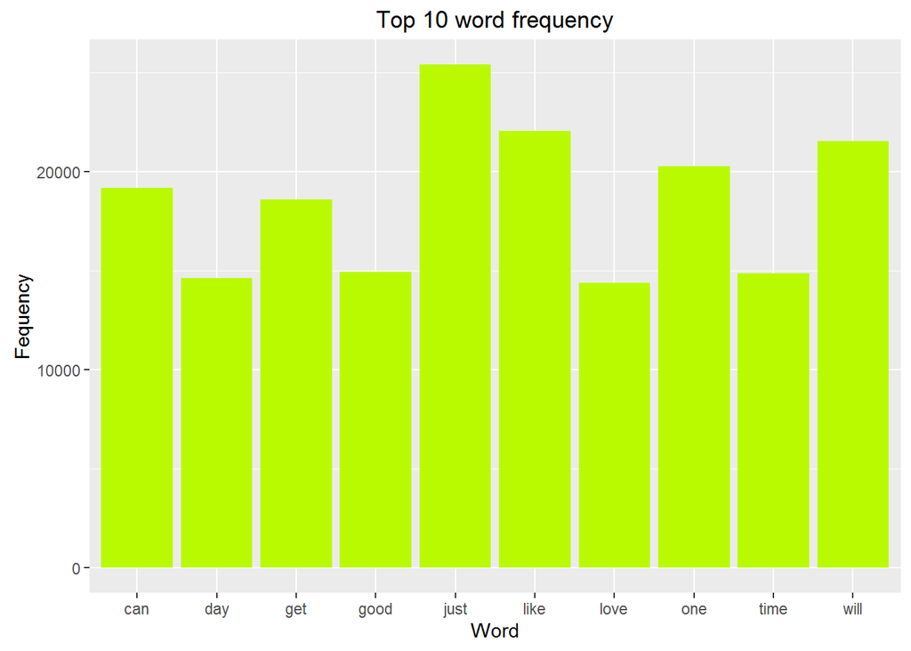

```r
top10 <- head(frequencyWords, 10)
top10Words <- data.frame(word=names(top10), freq=top10)
ggplot(top10Words, aes(word, freq)) + geom_bar(stat="identity",fill="#bafa00") + ggtitle("Top 10 word frequency") + xlab("Word") + ylab("Fequency") + labs(colour = "Cylinders")
```

Findings: It is nice to see that in the top 10 words we have: love, good, day, get, like… positive words.

## NGrams Token

We create three dimension tokens 1-gram, 2-gram and 3-gram and get from each the most frequent combinaison:

```r
dtmAll1g <- createDTM(corpusAllClean, OneGramTokenizer)
dtmAll2g <- createDTM(corpusAllClean, BiGramTokenizer)
dtmAll3g <- createDTM(corpusAllClean, TriGramTokenizer)
```

```r
freqAll1g <- getFreqTerms(dtmAll1g, 500)
freqAll2g <- getFreqTerms(dtmAll2g, 250)
freqAll3g <- getFreqTerms(dtmAll3g, 50)
```

We plot for each token n-gram the top 20 best frequent combinaison:

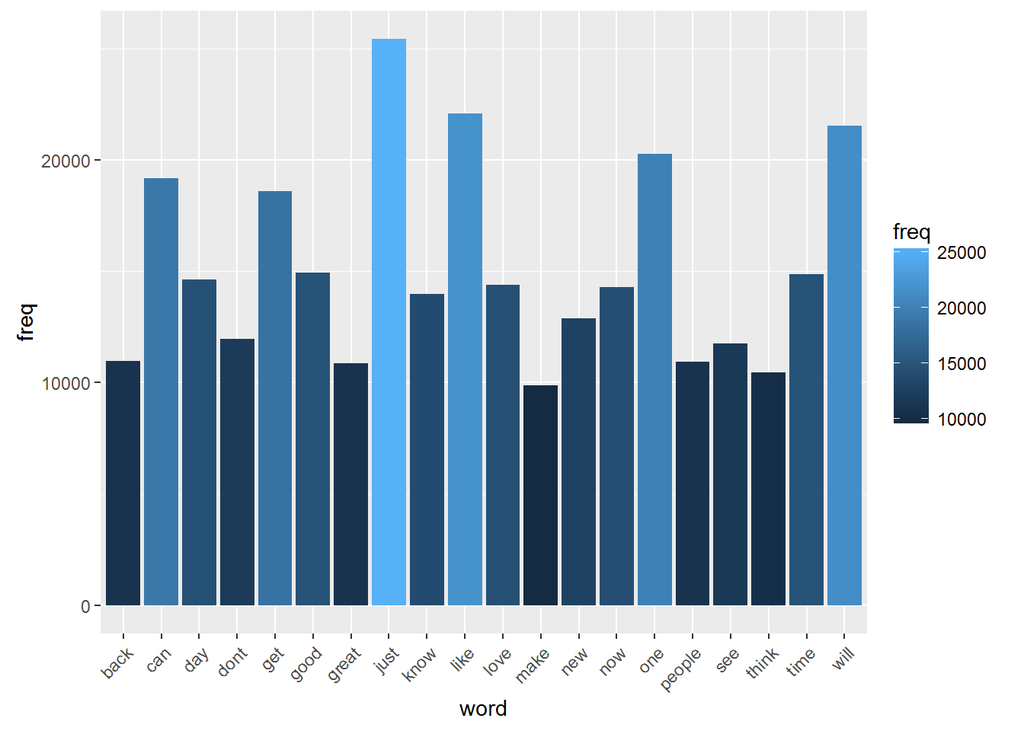

```r
plotFreqTerms(freqAll1g, 20)
```

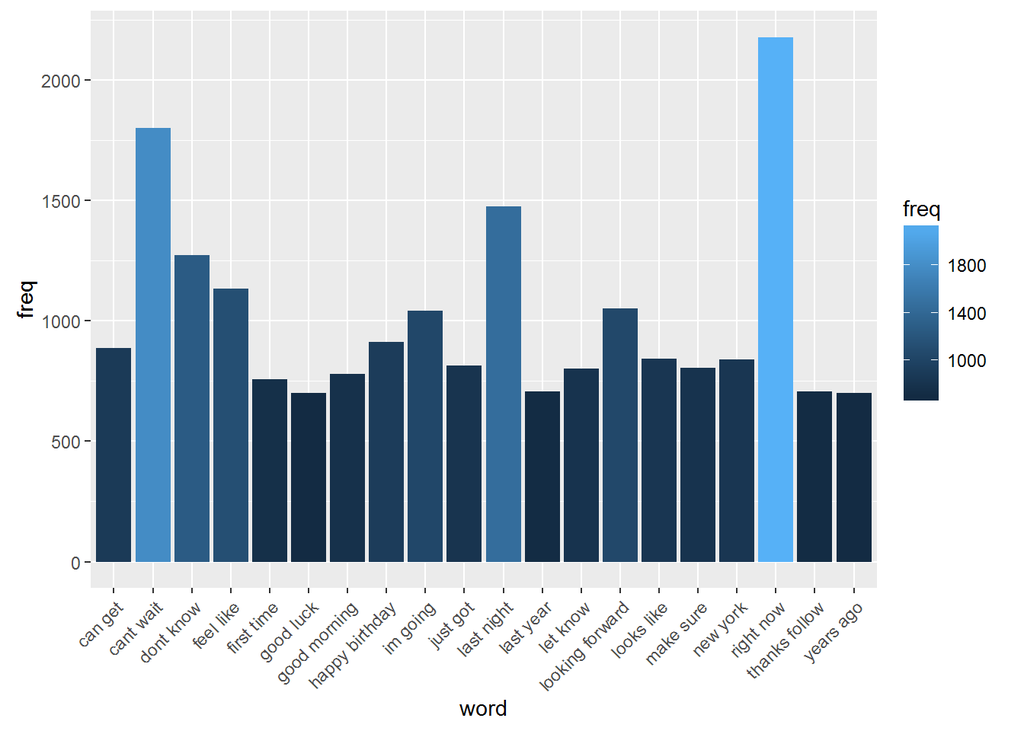

```r
plotFreqTerms(freqAll2g, 20)
```

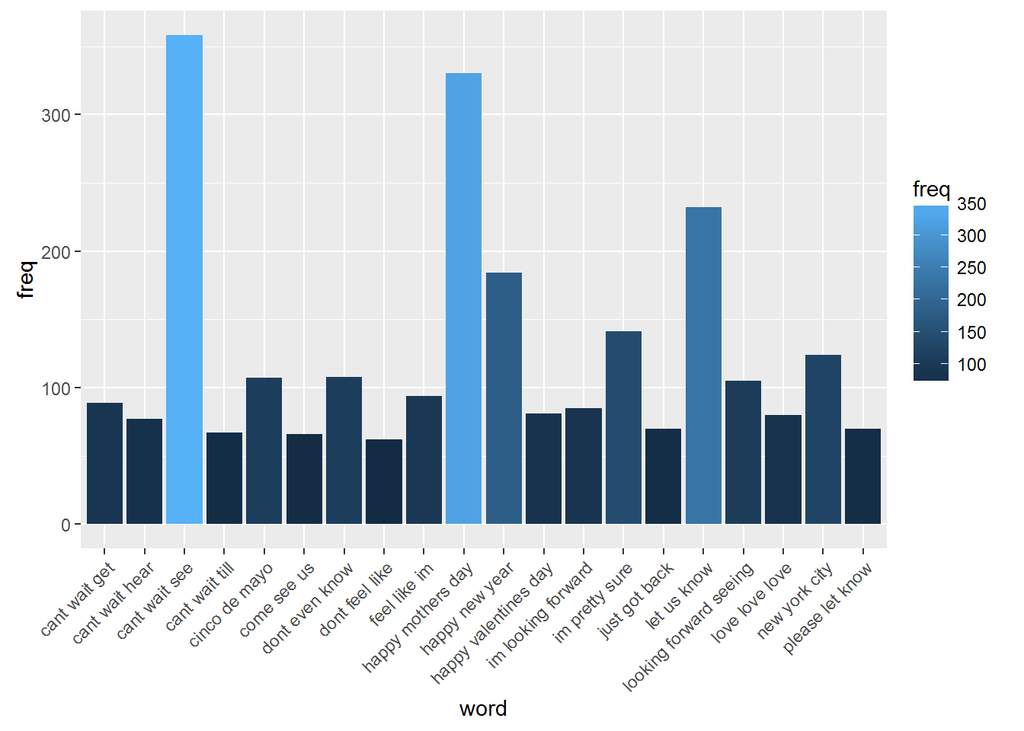

```r
plotFreqTerms(freqAll3g, 20)
```

## Coverage

[output not shown]

Get the coverage if we only get 50% or 90% of words of the copora:

```r
getCoverage(dtm_frame, 0.5)
```

```
## [1] 48818
```

```r
getCoverage(dtm_frame, 0.9)
```

```
## [1] 110653
```

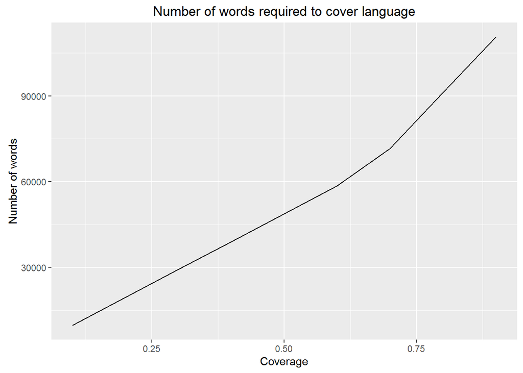

## Plan the future App

To predict words I am planning to use a straightforward approach: get the whole dataset, preprocess it and build different 1 to 4 gram matrices while predicting the next word with analyzing frequencies starting from the 4th gram (using 3 last words user typed). If nothing is found, use the next 3 gram (using 2 last words user typed), then 2 gram (using only last word user typed). I will also aside the n-grams work on word correlation to include in the next word prediction.

If nothing is found I will probably not recommend to the user anything.

If I encounter memory issues, I will try to reduct number of rows in each ngram to cover as much combinations as possible with less amount of memory. I will also give a prefered choice to the user with positive words.

That conlude this milestone report. Thank you!